# EXPLORATORY FACTOR ANALYSIS OF FACTORS INFLUENCING REANDING SCORES

Victor S Phiri

#EXPLORATORY FACTOR ANALYSIS OF FACTORS INFLUENCING REANDING SCORES

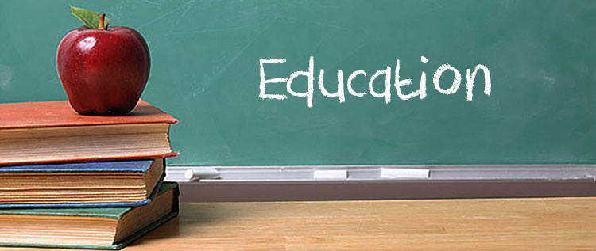

### Load packages

#### Load custom function

This will be used to visualise the results of the EFA

```r
fviz_loadnings_with_cor <- function(mod, axes = 1, loadings_above = 0.4){
  require(factoextra)
  require(dplyr)
  require(ggplot2)



if(!is.na(as.character(mod$call$call)[1])){
  if(as.character(mod$call$call)[1] == "PCA"){
  contrib_and_cov = as.data.frame(rbind(mod[["var"]][["contrib"]], mod[["var"]][["cor"]]))

vars = rownames(mod[["var"]][["contrib"]])
attribute_type = rep(c("contribution","correlation"), each = length(vars))
contrib_and_cov = cbind(contrib_and_cov, attribute_type)
contrib_and_cov

plot_data = cbind(as.data.frame(cbind(contrib_and_cov[contrib_and_cov[,"attribute_type"] == "contribution",axes], contrib_and_cov[contrib_and_cov[,"attribute_type"] == "correlation",axes])), vars)
names(plot_data) = c("contribution", "correlation", "vars")

plot_data = plot_data %>%
  mutate(correlation = round(correlation, 2))

plot = plot_data %>%
  ggplot() +
  aes(x = reorder(vars, contribution), y = contribution, gradient = correlation, label = correlation)+
  geom_col(aes(fill = correlation)) +
  geom_hline(yintercept = mean(plot_data$contribution), col = "red", lty = "dashed") + scale_fill_gradient2() +
  xlab("variable") +
  coord_flip() +
  geom_label(color = "black", fontface = "bold", position = position_dodge(0.5))


}
} else if(!is.na(as.character(mod$Call)[1])){

  if(as.character(mod$Call)[1] == "fa"){
    loadings_table = mod$loadings %>%
      matrix(ncol = ncol(mod$loadings)) %>%
      as_tibble() %>%
      mutate(variable = mod$loadings %>% rownames()) %>%
      gather(factor, loading, -variable) %>%
      mutate(sign = if_else(loading >= 0, "positive", "negative"))

  if(!is.null(loadings_above)){
    loadings_table[abs(loadings_table[,"loading"]) < loadings_above,"loading"] = NA
    loadings_table = loadings_table[!is.na(loadings_table[,"loading"]),]
  }

  if(!is.null(axes)){

  loadings_table = loadings_table %>%
     filter(factor == paste0("V",axes))
  }


  plot = loadings_table %>%
      ggplot() +
      aes(y = loading %>% abs(), x = reorder(variable, abs(loading)), fill = loading, label =       round(loading, 2)) +
      geom_col(position = "dodge") +
      scale_fill_gradient2() +
      coord_flip() +
      geom_label(color = "black", fill = "white", fontface = "bold", position = position_dodge(0.5)) +
      facet_wrap(~factor) +
      labs(y = "Loading strength", x = "Variable")
  }
}
return(plot)

}
```

#### Load data

```r
df <- read_sav("education.sav")
sum(is.na(df))
```

```
## [1] 13522
```

```r
sum(!is.na(df))
```

```
## [1] 264836
```

```r
library(VIM)
```

[figure not shown]

```r
ms<-aggr(df,plot = FALSE)
 plot(ms,numbers=TRUE,cex.numbers=.8)
```

#### Check for missing values

5% of the data has missing values, hence we drop them from the datset

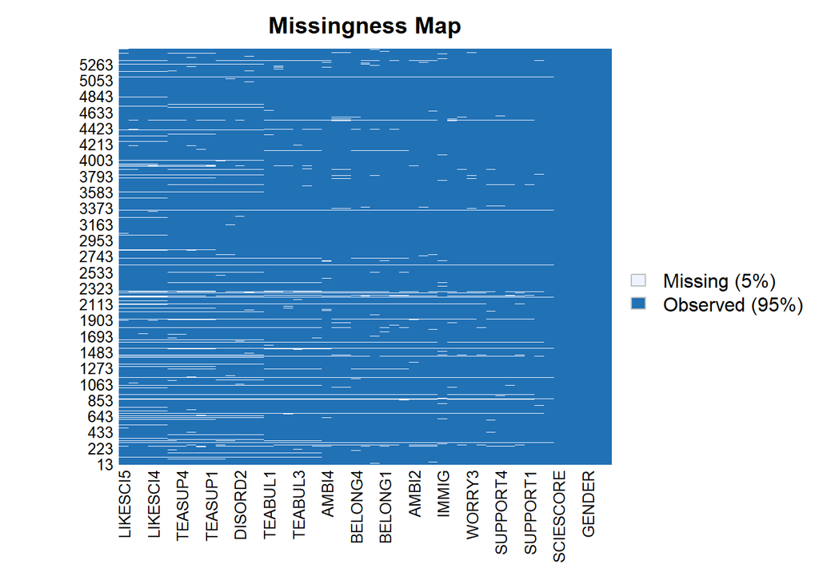

```r
missmap(df)
```

##### Drop anas

We removed NAs because they were five percent of the data

```r
df1<-df %>% drop_na()
```

#### Explore the data

```r
describe(df1) %>% knitr::kable(digits = 2)
```

|  | vars | n | mean | sd | median | trimmed | mad | min | max | range | skew | kurtosis | se |
| --- | --- | --- | --- | --- | --- | --- | --- | --- | --- | --- | --- | --- | --- |
| SCHOOLID | 1 | 3981 | 75200104.97 | 60.46 | 75200107.00 | 75200105.27 | 81.54 | 7.5200e+07 | 75200206.00 | 205.00 | -0.04 | -1.25 | 0.96 |
| STUDID | 2 | 3981 | 75203172.82 | 1829.52 | 75203183.00 | 75203173.39 | 2329.16 | 7.5200e+07 | 75206350.00 | 6349.00 | -0.01 | -1.20 | 29.00 |
| GENDER | 3 | 3981 | 1.47 | 0.50 | 1.00 | 1.46 | 0.00 | 1.0000e+00 | 2.00 | 1.00 | 0.11 | -1.99 | 0.01 |
| BOOKS | 4 | 3981 | 3.51 | 1.43 | 3.00 | 3.50 | 1.48 | 1.0000e+00 | 6.00 | 5.00 | 0.04 | -0.77 | 0.02 |
| SUPPORT1 | 5 | 3981 | 3.42 | 0.68 | 4.00 | 3.51 | 0.00 | 1.0000e+00 | 4.00 | 3.00 | -1.15 | 1.56 | 0.01 |
| SUPPORT2 | 6 | 3981 | 3.57 | 0.64 | 4.00 | 3.67 | 0.00 | 1.0000e+00 | 4.00 | 3.00 | -1.57 | 2.74 | 0.01 |
| SUPPORT3 | 7 | 3981 | 3.51 | 0.69 | 4.00 | 3.63 | 0.00 | 1.0000e+00 | 4.00 | 3.00 | -1.47 | 2.16 | 0.01 |
| SUPPORT4 | 8 | 3981 | 3.52 | 0.70 | 4.00 | 3.64 | 0.00 | 1.0000e+00 | 4.00 | 3.00 | -1.53 | 2.27 | 0.01 |
| WORRY1 | 9 | 3981 | 2.57 | 0.88 | 3.00 | 2.59 | 1.48 | 1.0000e+00 | 4.00 | 3.00 | -0.08 | -0.71 | 0.01 |
| WORRY2 | 10 | 3981 | 2.60 | 0.94 | 3.00 | 2.63 | 1.48 | 1.0000e+00 | 4.00 | 3.00 | -0.09 | -0.88 | 0.01 |
| WORRY3 | 11 | 3981 | 2.72 | 0.91 | 3.00 | 2.78 | 1.48 | 1.0000e+00 | 4.00 | 3.00 | -0.25 | -0.73 | 0.01 |
| WORRY4 | 12 | 3981 | 2.33 | 0.88 | 2.00 | 2.28 | 1.48 | 1.0000e+00 | 4.00 | 3.00 | 0.21 | -0.67 | 0.01 |
| WORRY5 | 13 | 3981 | 2.67 | 0.90 | 3.00 | 2.71 | 1.48 | 1.0000e+00 | 4.00 | 3.00 | -0.19 | -0.73 | 0.01 |
| Worry_sum | 14 | 3981 | 12.89 | 3.57 | 13.00 | 12.91 | 2.97 | 5.0000e+00 | 20.00 | 15.00 | -0.05 | -0.37 | 0.06 |
| worry.sum | 15 | 3981 | 12.89 | 3.57 | 13.00 | 12.91 | 2.97 | 5.0000e+00 | 20.00 | 15.00 | -0.05 | -0.37 | 0.06 |
| AMBI1 | 16 | 3981 | 3.24 | 0.83 | 3.00 | 3.33 | 1.48 | 1.0000e+00 | 9.00 | 8.00 | -0.37 | 1.76 | 0.01 |
| AMBI2 | 17 | 3981 | 3.50 | 0.66 | 4.00 | 3.60 | 0.00 | 1.0000e+00 | 4.00 | 3.00 | -1.23 | 1.40 | 0.01 |
| AMBI3 | 18 | 3981 | 3.08 | 0.85 | 3.00 | 3.14 | 1.48 | 1.0000e+00 | 4.00 | 3.00 | -0.42 | -0.86 | 0.01 |
| AMBI4 | 19 | 3981 | 3.12 | 0.73 | 3.00 | 3.18 | 0.00 | 1.0000e+00 | 4.00 | 3.00 | -0.56 | 0.18 | 0.01 |
| AMBI5 | 20 | 3981 | 2.90 | 0.92 | 3.00 | 2.96 | 1.48 | 1.0000e+00 | 4.00 | 3.00 | -0.31 | -0.92 | 0.01 |
| BELONG1 | 21 | 3981 | 3.18 | 0.96 | 3.00 | 3.35 | 1.48 | 1.0000e+00 | 4.00 | 3.00 | -1.02 | 0.02 | 0.02 |
| BELONG2 | 22 | 3981 | 2.05 | 0.86 | 2.00 | 1.96 | 1.48 | 1.0000e+00 | 4.00 | 3.00 | 0.64 | -0.11 | 0.01 |
| BELONG3 | 23 | 3981 | 2.16 | 0.88 | 2.00 | 2.08 | 1.48 | 1.0000e+00 | 4.00 | 3.00 | 0.51 | -0.38 | 0.01 |
| BELONG4 | 24 | 3981 | 3.18 | 0.96 | 3.00 | 3.35 | 1.48 | 1.0000e+00 | 4.00 | 3.00 | -1.03 | 0.06 | 0.02 |
| BELONG5 | 25 | 3981 | 2.07 | 0.76 | 2.00 | 2.01 | 0.00 | 1.0000e+00 | 4.00 | 3.00 | 0.73 | 0.68 | 0.01 |
| BELONG6 | 26 | 3981 | 3.21 | 0.96 | 3.00 | 3.39 | 1.48 | 1.0000e+00 | 4.00 | 3.00 | -1.09 | 0.18 | 0.02 |
| TEABUL1 | 27 | 3981 | 1.72 | 0.94 | 1.00 | 1.56 | 0.00 | 1.0000e+00 | 4.00 | 3.00 | 1.08 | 0.00 | 0.01 |
| TEABUL2 | 28 | 3981 | 1.66 | 0.87 | 1.00 | 1.51 | 0.00 | 1.0000e+00 | 4.00 | 3.00 | 1.17 | 0.44 | 0.01 |
| TEABUL3 | 29 | 3981 | 1.63 | 0.90 | 1.00 | 1.47 | 0.00 | 1.0000e+00 | 4.00 | 3.00 | 1.28 | 0.61 | 0.01 |
| TEABUL4 | 30 | 3981 | 1.37 | 0.77 | 1.00 | 1.17 | 0.00 | 1.0000e+00 | 4.00 | 3.00 | 2.14 | 3.75 | 0.01 |
| TEABUL5 | 31 | 3981 | 1.42 | 0.76 | 1.00 | 1.23 | 0.00 | 1.0000e+00 | 4.00 | 3.00 | 1.88 | 2.84 | 0.01 |
| TEABUL6 | 32 | 3981 | 1.28 | 0.65 | 1.00 | 1.11 | 0.00 | 1.0000e+00 | 4.00 | 3.00 | 2.63 | 6.66 | 0.01 |
| DISORD1 | 33 | 3981 | 2.84 | 0.83 | 3.00 | 2.90 | 0.00 | 1.0000e+00 | 4.00 | 3.00 | -0.49 | -0.19 | 0.01 |
| DISORD2 | 34 | 3981 | 2.80 | 0.82 | 3.00 | 2.84 | 0.00 | 1.0000e+00 | 4.00 | 3.00 | -0.45 | -0.19 | 0.01 |
| DISORD3 | 35 | 3981 | 2.91 | 0.87 | 3.00 | 2.98 | 1.48 | 1.0000e+00 | 4.00 | 3.00 | -0.51 | -0.36 | 0.01 |
| DISORD4 | 36 | 3981 | 3.05 | 0.81 | 3.00 | 3.13 | 1.48 | 1.0000e+00 | 4.00 | 3.00 | -0.65 | 0.06 | 0.01 |
| DISORD5 | 37 | 3981 | 2.99 | 0.85 | 3.00 | 3.06 | 1.48 | 1.0000e+00 | 4.00 | 3.00 | -0.59 | -0.20 | 0.01 |
| TEASUP1 | 38 | 3981 | 1.86 | 0.90 | 2.00 | 1.75 | 1.48 | 1.0000e+00 | 4.00 | 3.00 | 0.79 | -0.26 | 0.01 |
| TEASUP2 | 39 | 3981 | 1.92 | 0.93 | 2.00 | 1.81 | 1.48 | 1.0000e+00 | 4.00 | 3.00 | 0.68 | -0.52 | 0.01 |
| TEASUP3 | 40 | 3981 | 1.76 | 0.86 | 2.00 | 1.64 | 1.48 | 1.0000e+00 | 4.00 | 3.00 | 0.90 | -0.06 | 0.01 |
| TEASUP4 | 41 | 3981 | 1.90 | 0.95 | 2.00 | 1.78 | 1.48 | 1.0000e+00 | 4.00 | 3.00 | 0.73 | -0.55 | 0.02 |
| TEASUP5 | 42 | 3981 | 1.90 | 0.90 | 2.00 | 1.80 | 1.48 | 1.0000e+00 | 4.00 | 3.00 | 0.66 | -0.53 | 0.01 |
| LIKESCI1 | 43 | 3981 | 2.24 | 0.95 | 2.00 | 2.17 | 1.48 | 1.0000e+00 | 4.00 | 3.00 | 0.41 | -0.71 | 0.02 |
| LIKESCI2 | 44 | 3981 | 2.65 | 0.95 | 3.00 | 2.68 | 1.48 | 1.0000e+00 | 4.00 | 3.00 | -0.20 | -0.87 | 0.02 |
| LIKESCI3 | 45 | 3981 | 2.47 | 0.93 | 2.00 | 2.47 | 1.48 | 1.0000e+00 | 4.00 | 3.00 | 0.07 | -0.85 | 0.01 |
| LIKESCI4 | 46 | 3981 | 2.77 | 0.93 | 3.00 | 2.84 | 1.48 | 1.0000e+00 | 4.00 | 3.00 | -0.46 | -0.60 | 0.01 |
| LIKESCI5 | 47 | 3981 | 2.74 | 0.95 | 3.00 | 2.80 | 1.48 | 1.0000e+00 | 4.00 | 3.00 | -0.37 | -0.76 | 0.02 |
| IMMIG | 48 | 3981 | 1.20 | 0.52 | 1.00 | 1.05 | 0.00 | 1.0000e+00 | 3.00 | 2.00 | 2.61 | 5.68 | 0.01 |
| MATHSCORE | 49 | 3981 | 510.44 | 81.29 | 510.42 | 510.68 | 82.99 | 2.0245e+02 | 771.18 | 568.72 | -0.05 | -0.01 | 1.29 |
| READSCORE | 50 | 3981 | 522.11 | 91.40 | 527.88 | 524.69 | 92.28 | 9.5960e+01 | 826.61 | 730.64 | -0.29 | 0.14 | 1.45 |
| SCIESCORE | 51 | 3981 | 512.43 | 94.32 | 513.88 | 513.13 | 97.11 | 1.6699e+02 | 845.61 | 678.62 | -0.06 | -0.14 | 1.49 |

#### create a correlation matrix

we start by selecting the variables of interest. All other variables will remain in the original dataset.

```r
df_selected <-subset(df1,select = SUPPORT1:READSCORE)
df_w<- subset(df_selected,select = -c(Worry_sum,
                                       worry.sum,MATHSCORE,
                                      READSCORE,IMMIG))
df_cor=cor(df_w)
```

#### Visualise the correlation structure

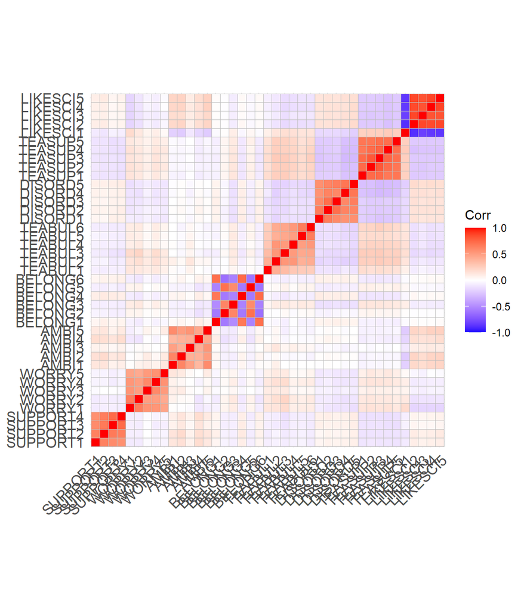

```r
ggcorrplot::ggcorrplot(df_cor)
```

#### Network Analysis

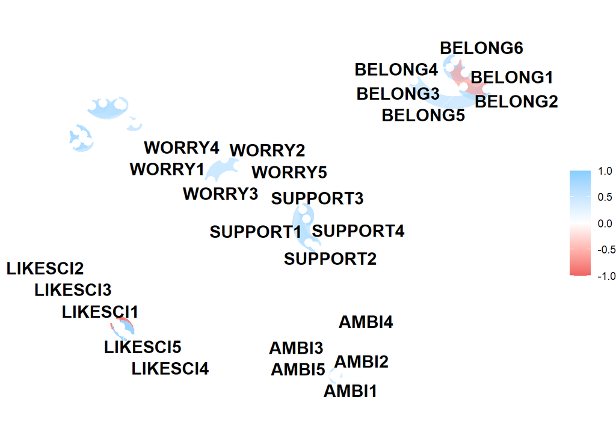

```r
library(corrr)
network_plot(df_cor,min_cor=0.6)
```

###Assumptions for Factorability

#### ## Kaiser-Meyer-Olkin (KMO) test

“A KMO value is a ratio of the sum of squared correlations to the sum of squared correlations plus the sum of squared partial correlations”. A minimum score of 0.6 is acceptable for EFA- (*Mvududu & Sink, 2013; Watson, 2017)*. Since our data has an overall score of 0.9, hence the data is factorable.

```r
 KMO(df_cor)
```

```
##
## -- Kaiser-Meyer-Olkin criterion (KMO) ------------------------------------------
##
## v The overall KMO value for your data is meritorious.
##   These data are probably suitable for factor analysis.
##
##   Overall: 0.897
##
##   For each variable:
## SUPPORT1 SUPPORT2 SUPPORT3 SUPPORT4   WORRY1   WORRY2   WORRY3   WORRY4
##    0.884    0.857    0.813    0.831    0.859    0.852    0.863    0.867
##   WORRY5    AMBI1    AMBI2    AMBI3    AMBI4    AMBI5  BELONG1  BELONG2
##    0.878    0.833    0.860    0.846    0.898    0.858    0.897    0.871
##  BELONG3  BELONG4  BELONG5  BELONG6  TEABUL1  TEABUL2  TEABUL3  TEABUL4
##    0.931    0.894    0.891    0.874    0.908    0.892    0.922    0.897
##  TEABUL5  TEABUL6  DISORD1  DISORD2  DISORD3  DISORD4  DISORD5  TEASUP1
##    0.842    0.847    0.926    0.879    0.896    0.908    0.906    0.945
##  TEASUP2  TEASUP3  TEASUP4  TEASUP5 LIKESCI1 LIKESCI2 LIKESCI3 LIKESCI4
##    0.915    0.912    0.940    0.942    0.936    0.909    0.940    0.930
## LIKESCI5
##    0.924
```

```r
 cortest.bartlett(df_cor)
```

```
## $chisq
## [1] 2191.019
##
## $p.value
## [1] 2.282342e-125
##
## $df
## [1] 820
```

#### ## MultivariateNormality mvnTest:

```r
library(MVN) # for mvn function
Output <- mvn(df_w, mvnTest = "hz")

Output$multivariateNormality
```

```
##            Test       HZ p value MVN
## 1 Henze-Zirkler 1.008226       0  NO
```

##### multivariate skew

The score of less than 0.05 violates the assumption of multivariate skewness

```r
library(ICS) # for multivariate skew and kurtosis test
mvnorm.skew.test(df_w)
```

```
##
##  Multivariate Normality Test Based on Skewness
##
## data:  df_w
## U = 5828.2, df = 41, p-value < 2.2e-16
```

### EFA

#### Choosing ideal number of factors

we run the parallel test, VSS technique and Kaiser Gutman criterion to determine the number of factors to include in our model.

#### Parallel Test

suggests 13 factors

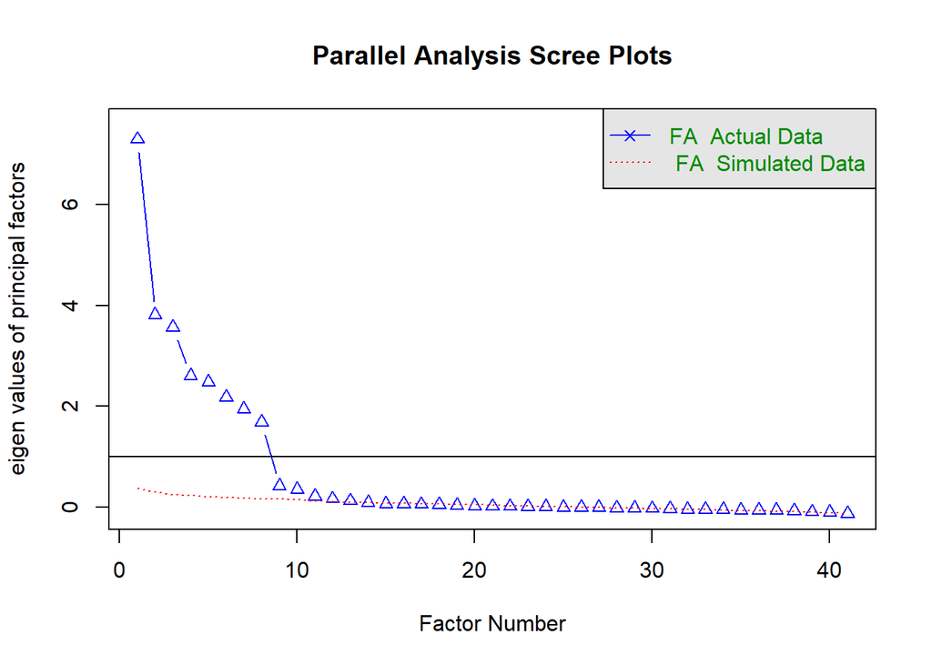

```
## Parallel analysis suggests that the number of factors =  13  and the number of components =  NA
```

```r
fa.parallel(df_cor, n.obs = nrow(df_w),nfactors = 10, fa = "fa",
            fm = "pa")
```

#### ## VSS technique

suggest 8, 8, 10,10 and 18 factors

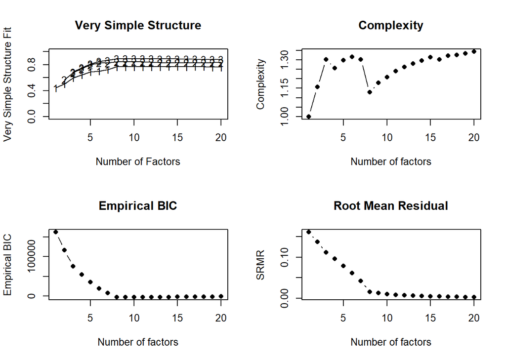

```
##
## Number of factors
## Call: vss(x = x, n = n, rotate = rotate, diagonal = diagonal, fm = fm,
##     n.obs = n.obs, plot = FALSE, title = title, use = use, cor = cor)
## VSS complexity 1 achieves a maximimum of Although the vss.max shows  15  factors, it is probably more reasonable to think about  8  factors
## VSS complexity 2 achieves a maximimum of 0.85  with  10  factors
## The Velicer MAP achieves a minimum of 0.01  with  8  factors
## Empirical BIC achieves a minimum of  -3081.78  with  10  factors
## Sample Size adjusted BIC achieves a minimum of  -756.92  with  18  factors
##
## Statistics by number of factors
##    vss1 vss2    map dof chisq     prob sqresid  fit RMSEA   BIC SABIC complex
## 1  0.44 0.00 0.0422 779 79893  0.0e+00    71.6 0.44 0.160 73436 75911     1.0
## 2  0.51 0.57 0.0435 739 60148  0.0e+00    55.4 0.57 0.142 54022 56370     1.2
## 3  0.60 0.68 0.0363 700 47316  0.0e+00    40.1 0.69 0.129 41513 43737     1.3
```

[output cut: 38 more lines]

```r
nfactors(df_cor, n.obs = nrow(df_w))
```

#### ## Kaiser Gutman criterion

suggests 8 factors

```r
library(FactoMineR)
KGC(df_cor,eigen_type = "EFA",n_factors = 10)
```

```
##
## Eigenvalues were found using EFA.
##
## -- Number of factors suggested by Kaiser-Guttmann criterion --------------------
##
## ( ) With EFA-determined eigenvalues:  8
```

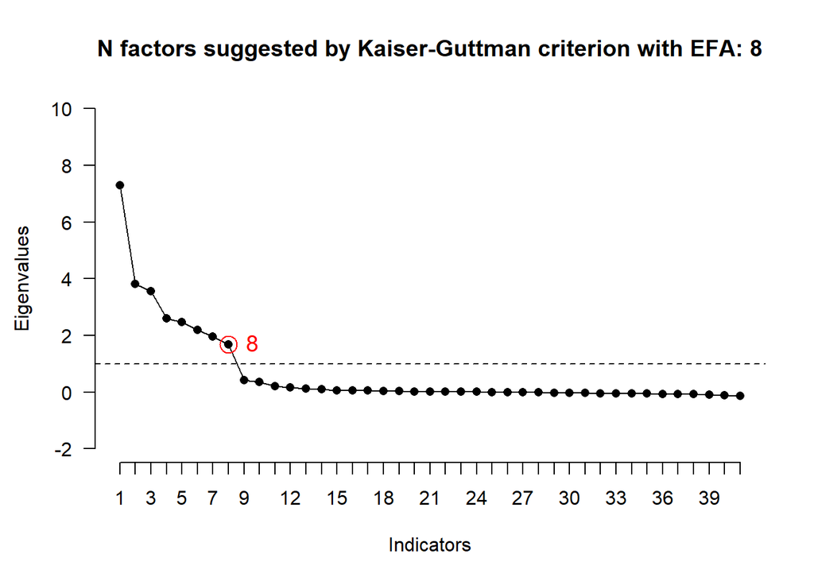

##### Comment

Using these three criteria, it appeared that 8 or 10 factors would be sufficient for an optimal balance between comprehensiveness and parsimony. Since both Velicer MAP, VSS and Kaiser Gutman criterion suggest 8 factors, we shall create our model with 8 factors.

#### create the first model

variable **LIKESCI2** (I like reading about science topics) has a highest communality value of 90% with the lowest being 20% **TEABUL1**(teachers called me less often than they called other students)

```r
mod1 <- fa(df_cor, nfactors = 8, fm = "pa")
mod1_comm<-as.data.frame(sort(mod1$communality, decreasing = TRUE))
#mod1_comm %>% knitr::kable(digits = 2)
### Factor Rotation
```

we prefer oblique rotation due to their accuracy and to honor the reality that most variables are correlated to some extent (Bandalos & Boehm-Kaufman, 2009). Schmitt (2011), argues that “because oblique rotation methods generally produce accurate and comparable factor structures to orthogonal methods even when interfactor correlations are negligible, it is strongly recommend that researchers only use oblique rotation methods because they generally result in more realistic and more statistically sound factor structures” (p. 312).

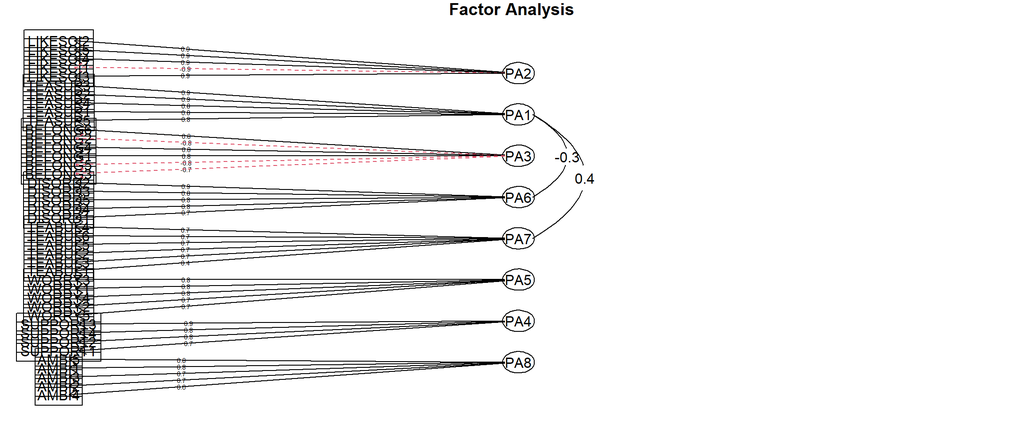

```r
fa.diagram(mod1)
```

#### PROMAX ROTATION

Among the potential oblique analytic rotations, promax was chosen because it is an oblique modification of the widely accepted varimax procedure (Gorsuch, 1983; Thompson, 2004).

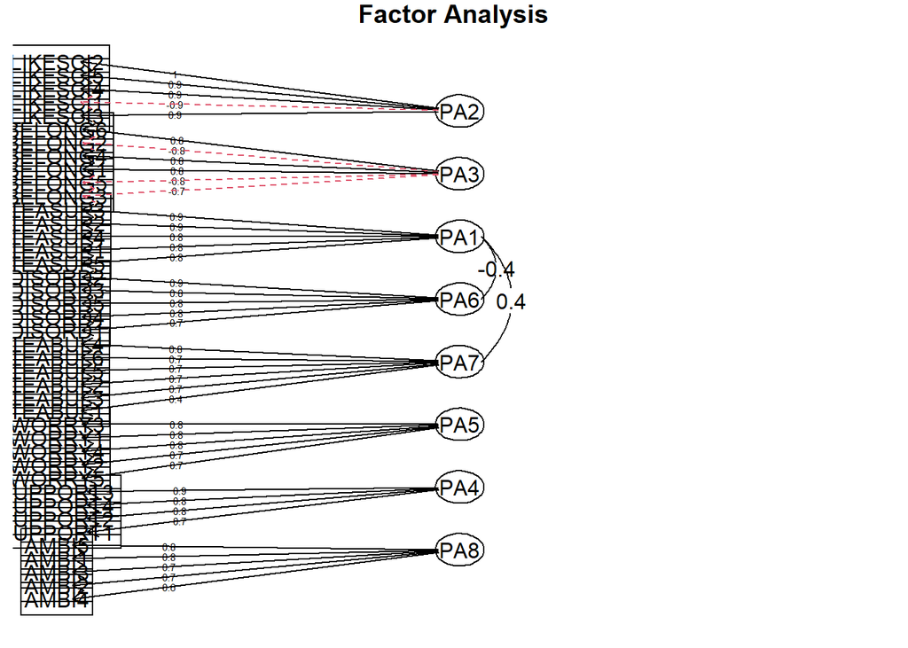

```r
EFA_promax <- fa(df_cor, nfactors = 8, fm="pa", rotate = "promax")# promax rotation

fa.diagram(EFA_promax)
```

#### Varimax Rotation

The varimax rotation does not consider the correlation between PA1,PA6,PA7. hence will we use the promax rotation.

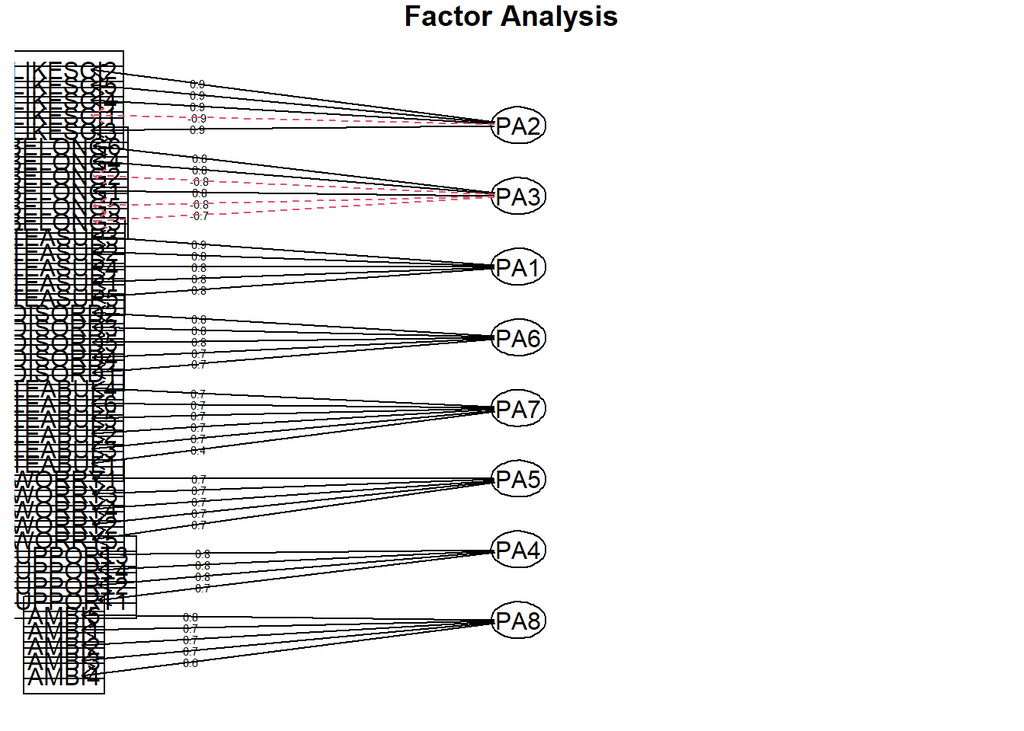

```r
EFA_varimax <- fa(df_cor, nfactors = 8,
                  fm="pa", rotate = "varimax")# varimax rotation
fa.diagram(EFA_varimax)
```

#### Factor Loadings

Comrey and Lee (1992) suggested that loadings greater than **.70** are excellent, **.63** are very good, **.55** are good, **.45** are fair, and **.32** are poor. Morin et al. (2020) concluded that loadings ≥.**50** are “fully satisfactory” (p. 1052). Hence we will accept loadings above **.50**

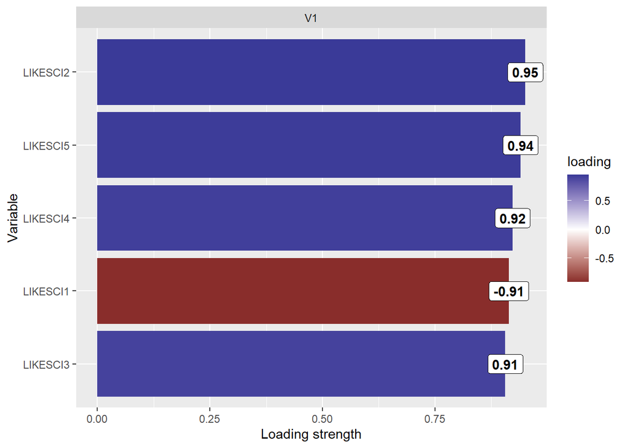

```r
fviz_loadnings_with_cor(EFA_promax, axes = 1, loadings_above = 0.55)
```

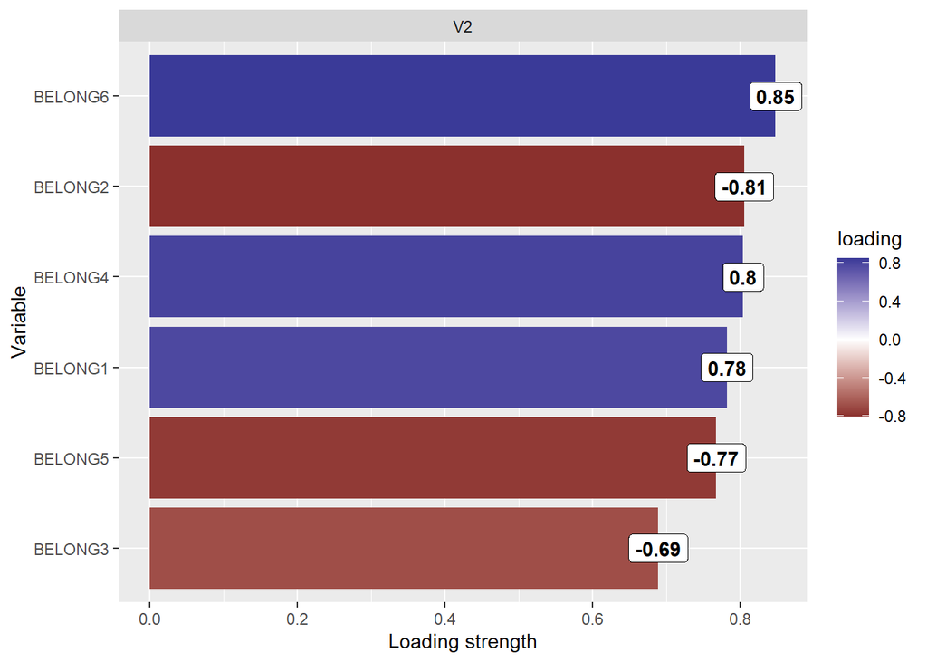

```r
fviz_loadnings_with_cor(EFA_promax, axes = 2, loadings_above = 0.55)
```

#### Select variables

We redo the process create the subset - by removing valuables with less influence

```r
df_w2 <- subset(df_w,
                select = -c(TEABUL1,AMBI4,AMBI3,TEABUL2,WORRY5,TEABUL3,TEABUL4,AMBI5))

df_Cor2 <- cor(df_w2)
```

parallel Test

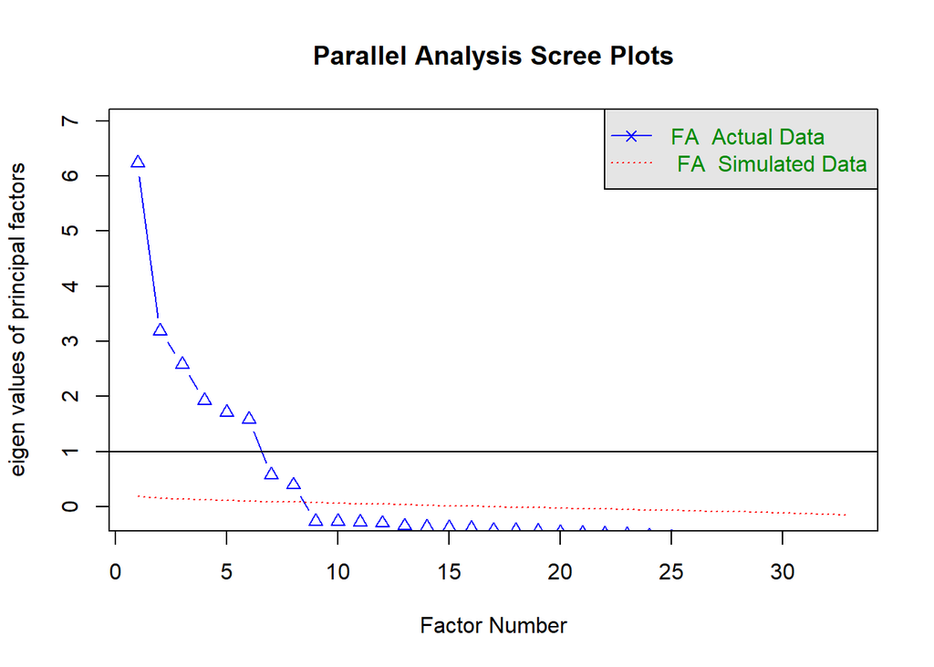

```
## Parallel analysis suggests that the number of factors =  8  and the number of components =  NA
```

```r
fa.parallel(df_Cor2, n.obs = nrow(df_w2), fa = "fa", fm = "pa")
```

#### VSS

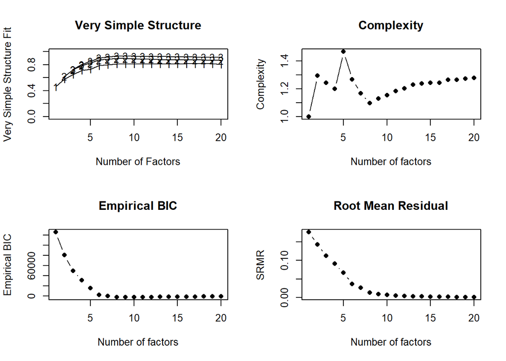

```
##
## Number of factors
## Call: vss(x = x, n = n, rotate = rotate, diagonal = diagonal, fm = fm,
##     n.obs = n.obs, plot = FALSE, title = title, use = use, cor = cor)
## VSS complexity 1 achieves a maximimum of Although the vss.max shows  18  factors, it is probably more reasonable to think about  13  factors
## VSS complexity 2 achieves a maximimum of 0.89  with  8  factors
## The Velicer MAP achieves a minimum of 0.01  with  6  factors
## Empirical BIC achieves a minimum of  -1877.28  with  9  factors
## Sample Size adjusted BIC achieves a minimum of  -564.5  with  14  factors
##
## Statistics by number of factors
##    vss1 vss2   map dof chisq     prob sqresid  fit  RMSEA   BIC SABIC complex
## 1  0.46 0.00 0.056 495 67677  0.0e+00    55.1 0.46 0.1846 63573 65146     1.0
## 2  0.58 0.62 0.057 463 52987  0.0e+00    39.0 0.62 0.1688 49149 50620     1.3
## 3  0.65 0.72 0.035 432 32254  0.0e+00    28.1 0.73 0.1360 28673 30046     1.2
```

[output cut: 38 more lines]

```r
nfactors(df_Cor2, n.obs = nrow(df_w2))
```

#### ## Kaiser Gutman criterion

```r
 KGC(df_Cor2,eigen_type = "EFA",n_factors = 8)
```

```
##
## Eigenvalues were found using EFA.
##
## -- Number of factors suggested by Kaiser-Guttmann criterion --------------------
##
## ( ) With EFA-determined eigenvalues:  7
```

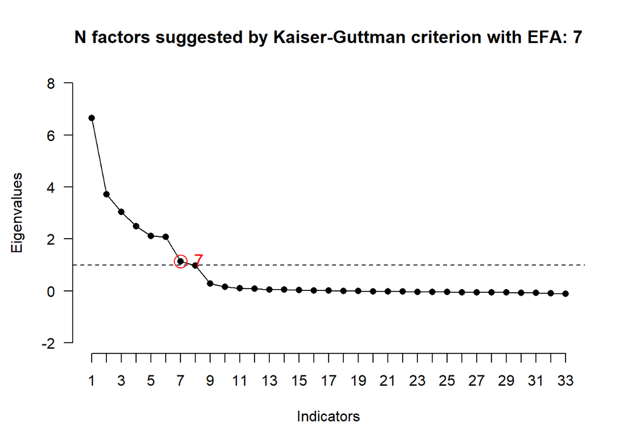

```r
EFA_mod3 <- fa(df_Cor2, nfactors = 8,
               fm = "pa", rotate = "promax")
EFA_mod3
```

```
## Factor Analysis using method =  pa
## Call: fa(r = df_Cor2, nfactors = 8, rotate = "promax", fm = "pa")
## Standardized loadings (pattern matrix) based upon correlation matrix
##            PA3   PA2   PA1   PA5   PA4   PA6   PA7   PA8   h2   u2 com
## SUPPORT1  0.01 -0.01  0.01  0.00  0.72 -0.02  0.01  0.04 0.52 0.48   1
## SUPPORT2  0.02  0.00  0.01 -0.02  0.81  0.01  0.01  0.04 0.67 0.33   1
## SUPPORT3 -0.02 -0.01  0.00  0.01  0.86  0.00  0.00 -0.06 0.73 0.27   1
## SUPPORT4 -0.01  0.01 -0.01  0.01  0.82  0.01 -0.01 -0.03 0.67 0.33   1
## WORRY1   -0.06  0.00 -0.01  0.00 -0.01  0.79  0.01 -0.05 0.64 0.36   1
## WORRY2   -0.02 -0.04 -0.02 -0.01 -0.03  0.73  0.02  0.01 0.55 0.45   1
## WORRY3    0.03  0.03 -0.01  0.01  0.03  0.75 -0.04  0.04 0.55 0.45   1
## WORRY4    0.03  0.00  0.03  0.00  0.00  0.72  0.02  0.00 0.52 0.48   1
## AMBI1     0.00  0.00 -0.01 -0.01 -0.03  0.01  0.02  0.79 0.62 0.38   1
## AMBI2     0.00  0.00  0.01  0.01  0.03 -0.01 -0.02  0.78 0.63 0.37   1
## BELONG1  -0.01  0.78  0.02 -0.01 -0.01  0.00  0.01 -0.02 0.60 0.40   1
## BELONG2   0.01 -0.81 -0.02  0.03  0.01 -0.02 -0.03 -0.01 0.64 0.36   1
## BELONG3  -0.02 -0.69  0.02 -0.05  0.01  0.02  0.03 -0.02 0.51 0.49   1
## BELONG4  -0.01  0.80 -0.01  0.00  0.02 -0.01  0.00  0.00 0.65 0.35   1
## BELONG5  -0.01 -0.77 -0.01  0.00  0.00 -0.03  0.00 -0.01 0.59 0.41   1
## BELONG6  -0.01  0.85 -0.02 -0.02 -0.01 -0.01  0.00 -0.03 0.71 0.29   1
## TEABUL5  -0.01  0.00 -0.03  0.00  0.01 -0.01  0.81  0.01 0.65 0.35   1
## TEABUL6   0.01  0.01  0.02  0.00  0.00  0.00  0.82 -0.01 0.67 0.33   1
## DISORD1   0.00  0.01  0.00  0.74  0.00  0.02  0.00 -0.01 0.55 0.45   1
## DISORD2  -0.01  0.01  0.04  0.86  0.00  0.01  0.03  0.02 0.71 0.29   1
## DISORD3  -0.01  0.00  0.05  0.84 -0.01 -0.02  0.02  0.02 0.67 0.33   1
## DISORD4   0.00  0.00 -0.05  0.76 -0.01 -0.01 -0.01 -0.02 0.61 0.39   1
## DISORD5   0.02 -0.02 -0.04  0.77  0.02  0.00 -0.03 -0.01 0.64 0.36   1
## TEASUP1   0.01  0.00  0.83  0.01  0.00  0.00  0.00 -0.02 0.68 0.32   1
## TEASUP2   0.02  0.00  0.88  0.01  0.01  0.02  0.00 -0.01 0.77 0.23   1
## TEASUP3   0.02  0.00  0.90  0.00  0.02  0.00  0.01 -0.01 0.81 0.19   1
## TEASUP4  -0.03  0.01  0.84  0.00 -0.01  0.00  0.00  0.02 0.72 0.28   1
## TEASUP5  -0.02  0.00  0.82 -0.01 -0.02 -0.02 -0.02  0.02 0.67 0.33   1
## LIKESCI1 -0.91  0.00  0.01 -0.01 -0.01  0.00  0.01 -0.01 0.85 0.15   1
## LIKESCI2  0.95  0.00  0.01  0.00  0.00  0.00 -0.01 -0.01 0.90 0.10   1
## LIKESCI3  0.91  0.00 -0.01 -0.01 -0.01 -0.01  0.03 -0.03 0.81 0.19   1
## LIKESCI4  0.92  0.00  0.01  0.00 -0.01  0.00 -0.01  0.01 0.85 0.15   1
## LIKESCI5  0.94  0.00  0.01 -0.01  0.00  0.01  0.01  0.01 0.88 0.12   1
##
##                        PA3  PA2  PA1  PA5  PA4  PA6  PA7  PA8
## SS loadings           4.30 3.68 3.66 3.17 2.60 2.24 1.33 1.25
```

[output cut: 20 more lines]

```
## The degrees of freedom for the model are 292  and the objective function was  0.67
##
## The root mean square of the residuals (RMSR) is  0.01
## The df corrected root mean square of the residuals is  0.02
##
## Fit based upon off diagonal values = 1
## Measures of factor score adequacy
##                                                    PA3  PA2  PA1  PA5  PA4  PA6
## Correlation of (regression) scores with factors   0.98 0.95 0.97 0.95 0.94 0.92
## Multiple R square of scores with factors          0.97 0.91 0.94 0.90 0.89 0.84
## Minimum correlation of possible factor scores     0.94 0.82 0.87 0.80 0.78 0.68
##                                                    PA7  PA8
## Correlation of (regression) scores with factors   0.90 0.88
## Multiple R square of scores with factors          0.80 0.78
## Minimum correlation of possible factor scores     0.61 0.55
```

#### Final model

loadings above 0.5

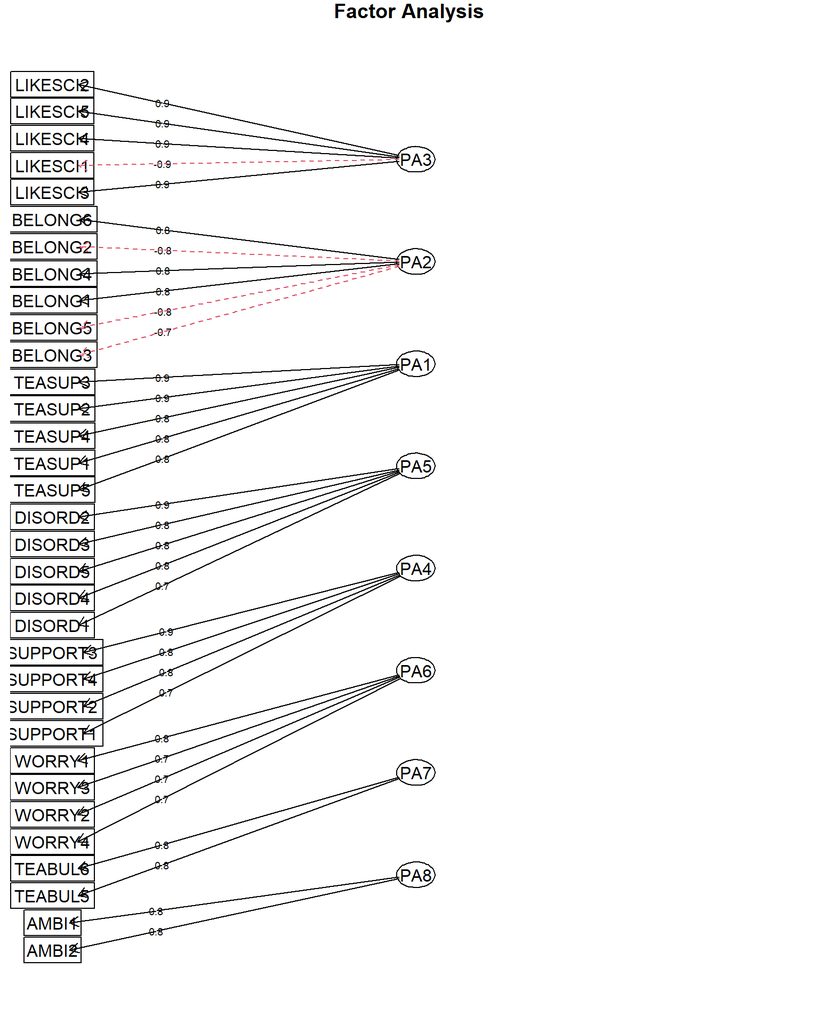

```r
fa.diagram(EFA_mod3,cut=0.5)# fator analysis structure
```

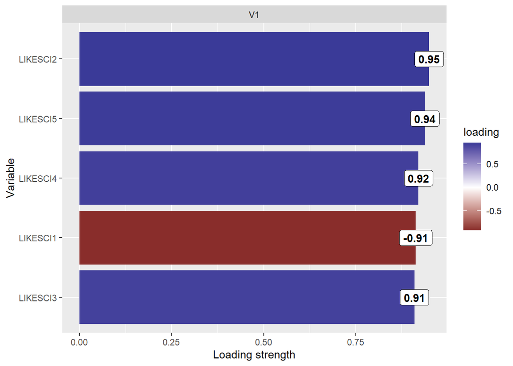

```r
fviz_loadnings_with_cor(EFA_mod3, axes = 1, loadings_above = 0.55)# loadings
```

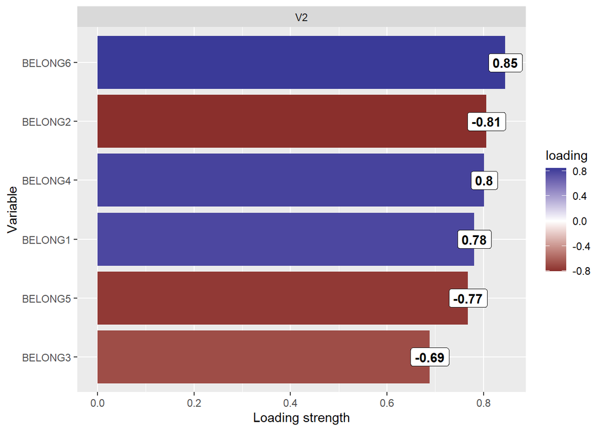

```r
fviz_loadnings_with_cor(EFA_mod3, axes = 2, loadings_above = 0.55)#loadings
```

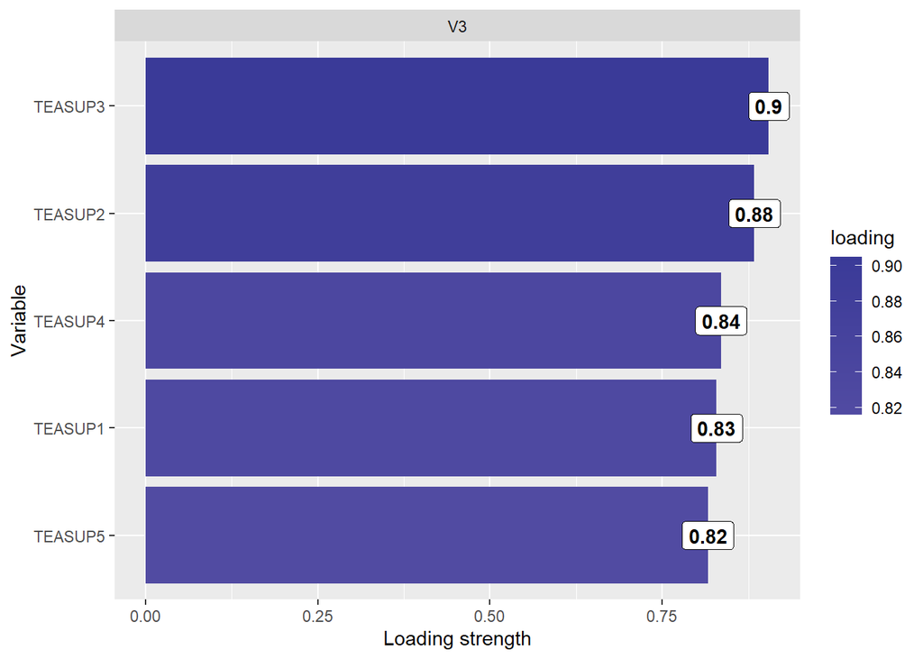

```r
fviz_loadnings_with_cor(EFA_mod3, axes = 3, loadings_above = 0.55)
```

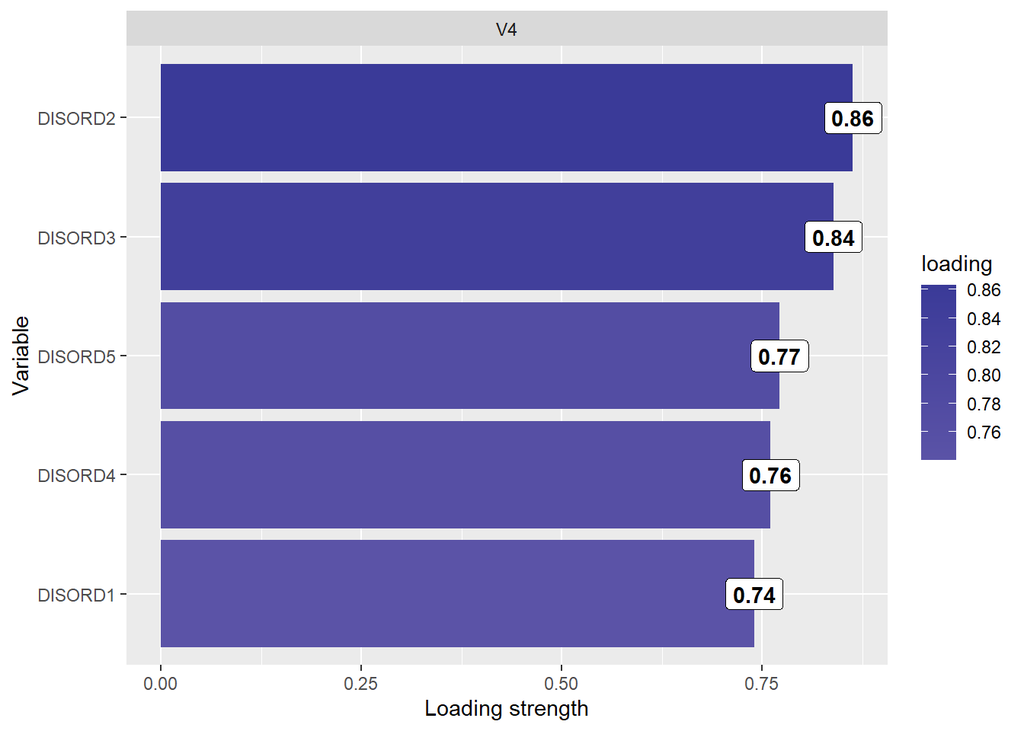

```r
fviz_loadnings_with_cor(EFA_mod3, axes = 4, loadings_above = 0.55)
```

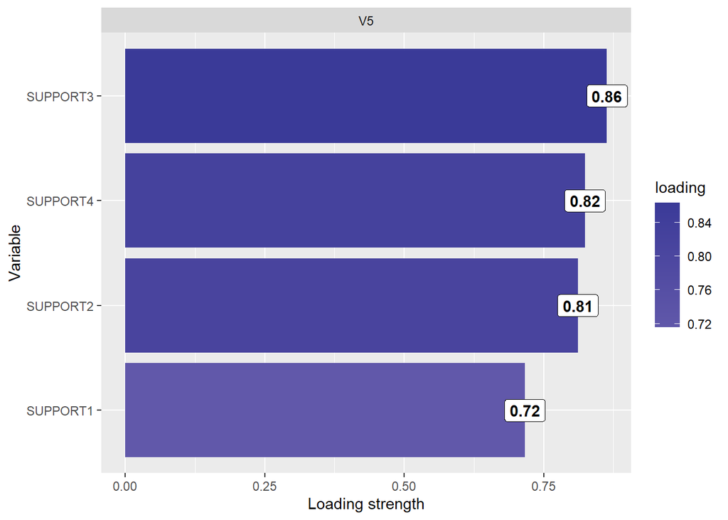

```r
fviz_loadnings_with_cor(EFA_mod3, axes = 5, loadings_above = 0.55)
```

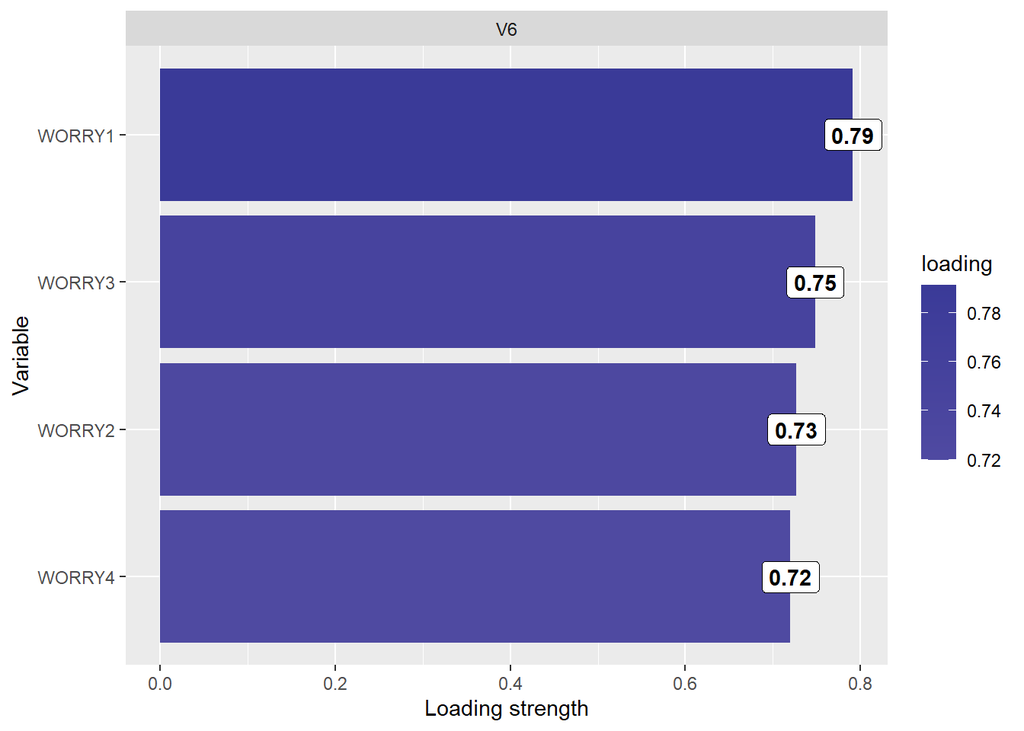

```r
fviz_loadnings_with_cor(EFA_mod3, axes = 6, loadings_above = 0.55)
```

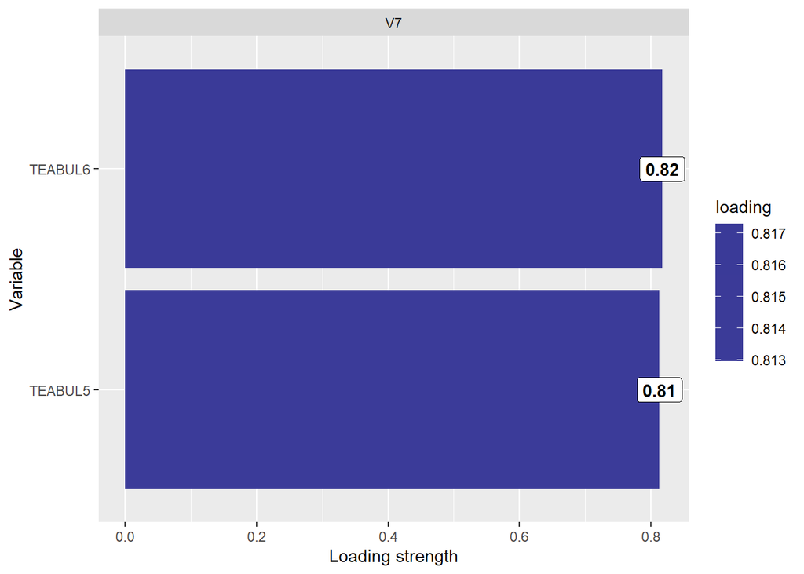

```r
fviz_loadnings_with_cor(EFA_mod3, axes = 7, loadings_above = 0.55)
```

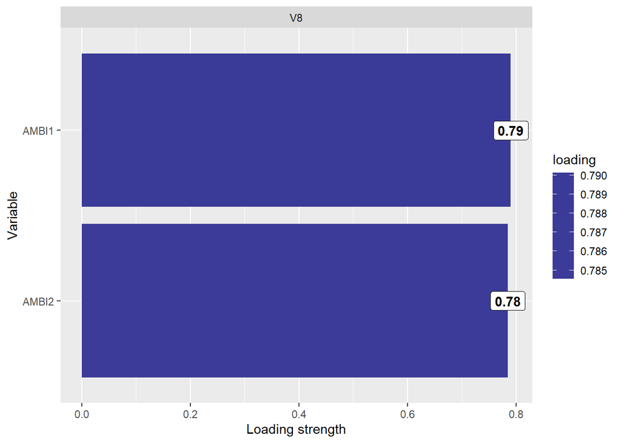

```r
fviz_loadnings_with_cor(EFA_mod3, axes = 8, loadings_above = 0.55)
```

##### Post extraction communality

```r
EFA_mod3_common <- as.data.frame(sort(EFA_mod3$communality,
                                      decreasing = TRUE))

EFA_mod3_common %>% knitr::kable(caption = "post Extration Communality Table",digits = 2)
```

post Extration Communality Table

|  | sort(EFA_mod3$communality, decreasing = TRUE) |
| --- | --- |
| LIKESCI2 | 0.90 |
| LIKESCI5 | 0.88 |
| LIKESCI1 | 0.85 |
| LIKESCI4 | 0.85 |
| TEASUP3 | 0.81 |
| LIKESCI3 | 0.81 |
| TEASUP2 | 0.77 |
| SUPPORT3 | 0.73 |
| TEASUP4 | 0.72 |
| BELONG6 | 0.71 |
| DISORD2 | 0.71 |
| TEASUP1 | 0.68 |
| TEABUL6 | 0.67 |
| SUPPORT4 | 0.67 |
| SUPPORT2 | 0.67 |
| DISORD3 | 0.67 |
| TEASUP5 | 0.67 |
| BELONG4 | 0.65 |
| TEABUL5 | 0.65 |
| WORRY1 | 0.64 |
| BELONG2 | 0.64 |
| DISORD5 | 0.64 |
| AMBI2 | 0.63 |
| AMBI1 | 0.62 |
| DISORD4 | 0.61 |
| BELONG1 | 0.60 |
| BELONG5 | 0.59 |
| DISORD1 | 0.55 |
| WORRY2 | 0.55 |
| WORRY3 | 0.55 |
| SUPPORT1 | 0.52 |
| WORRY4 | 0.52 |
| BELONG3 | 0.51 |

```r
mean(EFA_mod3$communality)
```

```
## [1] 0.673342
```

### Factor scores

we join the factor scores to the main dataset

```r
factorscores = factor.scores(df_w2, EFA_mod3)$scores
```

```r
variable_factorscores = cbind(df1, factorscores)
```

### Rename factors

we rename factors so we can make them easy to read

```r
variable_factorscores<-variable_factorscores %>%
  rename(TEASUPPORT=(PA1),
         LIKES=(PA2),
         BELONG=(PA3),
         PARENTSP=(PA4),
         WORRY=(PA5),
         DISCORD=(PA6),
         TEABUL=(PA7),
         AMBITIONS=(PA8))
```

##### save dataset with a new name

```r
df_clean<-variable_factorscores
df_final<-variable_factorscores
```

#### Recod gender into factor

It is presented as a numeric variable but we need to keep it as a categorical variable with two levels 1 female 2 male

```r
df_final$GENDER<- factor(df_final$GENDER)

df_final$GENDER<- recode_factor(df_final$GENDER,"1"="Female","2"="Male")
df_reg<- df_final %>% dplyr::select(BOOKS,GENDER,READSCORE,
                             BELONG,LIKES,TEASUPPORT,
                             DISCORD,WORRY,PARENTSP,TEABUL,AMBITIONS)
```

##### create training and test dataset

We split the data into training and testing set. 70% training while 30% testing. We use catTools package.

```r
set.seed(1)
library(caTools)
sample <- sample.split(df_reg$GENDER, SplitRatio = 0.70)
train  <- subset(df_reg, sample == TRUE)
test   <- subset(df_reg, sample == FALSE)

train$BOOKS<-as.numeric(train$BOOKS)
```

```r
library(GGally)
#ggpairs(train)
str(train)
```

```
## 'data.frame':    2786 obs. of  11 variables:
##  $ BOOKS     : num  3 2 3 3 3 4 4 5 2 6 ...
##  $ GENDER    : Factor w/ 2 levels "Female","Male": 1 1 1 1 1 1 1 1 1 1 ...
##  $ READSCORE : num  460 473 573 459 520 ...
##  $ BELONG    : num  -1.9 0.343 1.471 -1.908 0.212 ...
##  $ LIKES     : num  -1.104 -0.045 -0.8 0.352 0.638 ...
##  $ TEASUPPORT: num  2.567 1.226 1.036 2.317 -0.424 ...
##  $ DISCORD   : num  2.0444 0.6439 -0.0724 1.7228 -1.7868 ...
##  $ WORRY     : num  -0.32 -1.924 -1.834 -0.78 0.356 ...
##  $ PARENTSP  : num  -2.885 0.808 -0.447 -0.457 0.88 ...
##  $ TEABUL    : num  4.337 1.803 1.133 3.314 -0.597 ...
##  $ AMBITIONS : num  -0.529 0.945 0.915 -0.427 0.271 ...
```

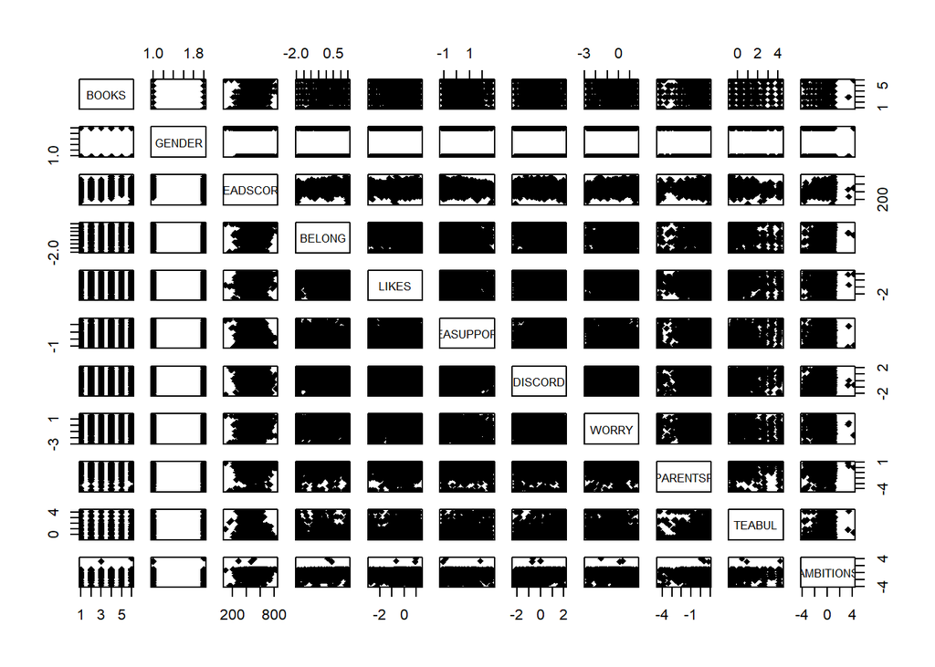

```r
pairs(train, pch = 18, col = "black")
```

```r
table1::table1(~BOOKS+READSCORE+
                             BELONG+LIKES+TEASUPPORT+
                             DISCORD+WORRY+PARENTSP+TEABUL+AMBITIONS|GENDER,caption="Descriptive Statistics",
                  data = train,transpose=FALSE,
               topclass="Rtable1-grid Rtable1-shade Rtable1-times")
```

Descriptive Statistics

|  | Female (N=1471) | Male (N=1315) | Overall (N=2786) |
| --- | --- | --- | --- |
| BOOKS |  |  |  |
| Mean (SD) | 3.61 (1.43) | 3.40 (1.44) | 3.51 (1.44) |
| Median [Min, Max] | 3.00 [1.00, 6.00] | 3.00 [1.00, 6.00] | 3.00 [1.00, 6.00] |
| READSCORE |  |  |  |
| Mean (SD) | 535 (87.7) | 506 (95.7) | 522 (92.7) |
| Median [Min, Max] | 541 [255, 827] | 507 [96.0, 819] | 527 [96.0, 827] |
| BELONG |  |  |  |
| Mean (SD) | -0.0934 (0.994) | 0.102 (1.01) | -0.00122 (1.00) |
| Median [Min, Max] | 0.0340 [-1.93, 1.50] | 0.333 [-1.93, 1.50] | 0.198 [-1.93, 1.50] |
| LIKES |  |  |  |
| Mean (SD) | -0.0494 (0.921) | 0.0498 (1.09) | -0.00259 (1.01) |
| Median [Min, Max] | 0.0941 [-2.80, 1.31] | 0.362 [-2.80, 1.32] | 0.184 [-2.80, 1.32] |
| TEASUPPORT |  |  |  |
| Mean (SD) | 0.0694 (1.01) | -0.0796 (0.975) | -0.000907 (0.995) |
| Median [Min, Max] | -0.0143 [-1.11, 2.78] | -0.248 [-1.13, 2.75] | -0.0867 [-1.13, 2.78] |
| DISCORD |  |  |  |
| Mean (SD) | 0.302 (0.938) | -0.330 (0.968) | 0.00392 (1.00) |
| Median [Min, Max] | 0.298 [-2.18, 2.07] | -0.421 [-2.24, 2.06] | -0.0115 [-2.24, 2.07] |
| WORRY |  |  |  |
| Mean (SD) | -0.0587 (0.990) | 0.0421 (1.02) | -0.0111 (1.01) |
| Median [Min, Max] | 0.108 [-2.84, 1.60] | 0.148 [-2.80, 1.60] | 0.127 [-2.84, 1.60] |
| PARENTSP |  |  |  |
| Mean (SD) | 0.0296 (0.961) | -0.0595 (1.06) | -0.0124 (1.01) |
| Median [Min, Max] | 0.371 [-4.29, 0.892] | 0.256 [-4.40, 0.893] | 0.315 [-4.40, 0.893] |
| TEABUL |  |  |  |
| Mean (SD) | -0.0360 (0.930) | 0.0348 (1.06) | -0.00262 (0.996) |
| Median [Min, Max] | -0.488 [-0.698, 4.34] | -0.499 [-0.702, 4.28] | -0.493 [-0.702, 4.34] |
| AMBITIONS |  |  |  |
| Mean (SD) | 0.0920 (0.938) | -0.0922 (1.05) | 0.00506 (0.999) |
| Median [Min, Max] | 0.277 [-3.87, 3.45] | 0.159 [-3.87, 4.18] | 0.248 [-3.87, 4.18] |

### Visualise

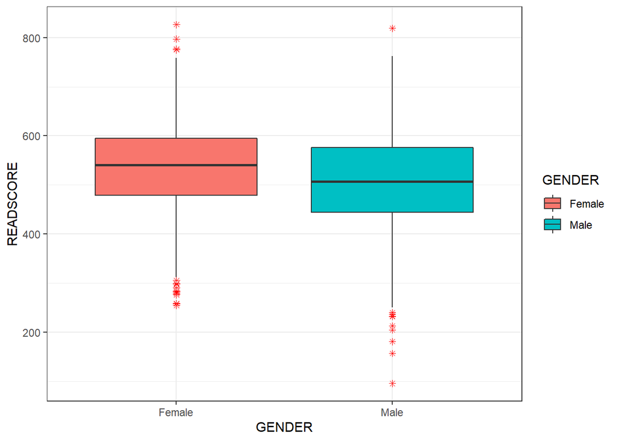

```r
ggplot(train,aes(GENDER,READSCORE,fill=GENDER))+
  geom_boxplot(outlier.shape = 8,outlier.colour = "red")+
  theme_bw()
```

#Dependant variable The data is normally distributed

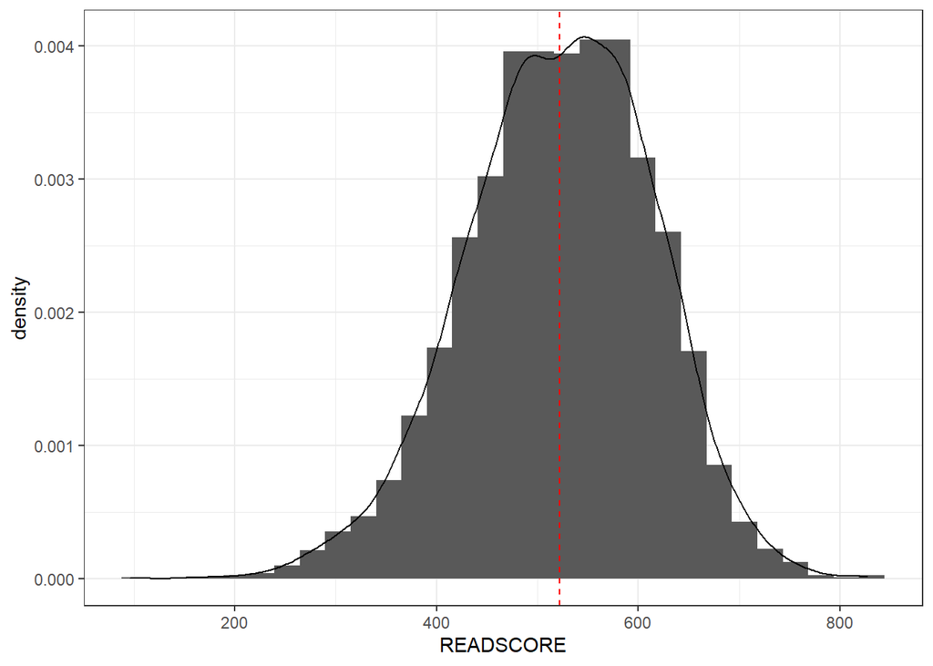

```r
ggplot(train,aes(READSCORE,..density..))+
  geom_histogram()+
  geom_density()+
  geom_vline(aes(xintercept = mean(READSCORE)),
                 color="red",linetype="dashed")+
  theme_bw()
```

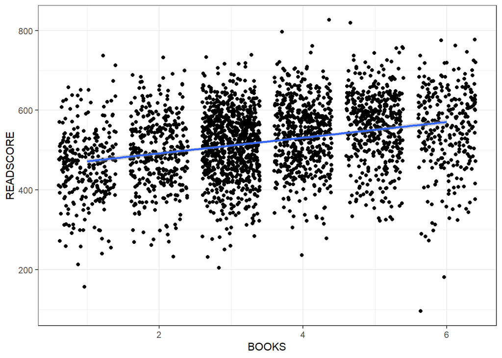

```r
ggplot(train,aes(BOOKS,READSCORE))+
  geom_point(position="jitter")+
  geom_smooth(method = "lm")+
  theme_bw()
```

# Reading score and Teacher support

Weak negative relationship

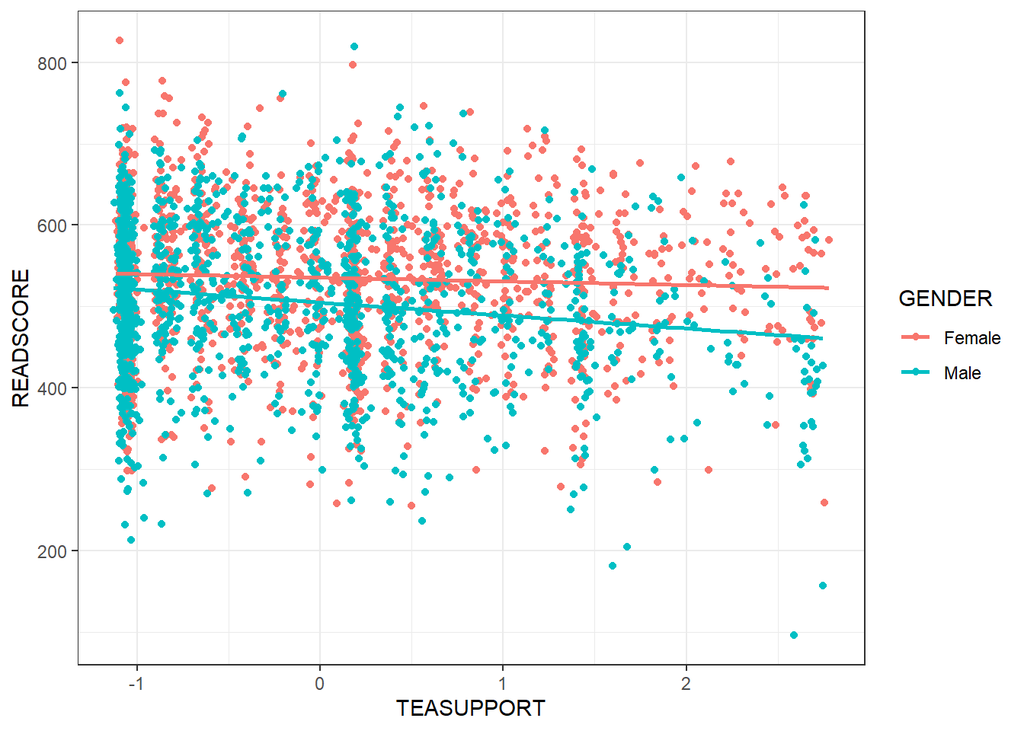

```r
ggplot(train,aes(TEASUPPORT,READSCORE,color=GENDER))+
  geom_point()+
  theme_bw()+
  geom_smooth(method = "lm",se=FALSE)
```

```r
cor(train$READSCORE,train$TEASUPPORT)
```

```
## [1] -0.09194776
```

#teacher bullying and Reading score

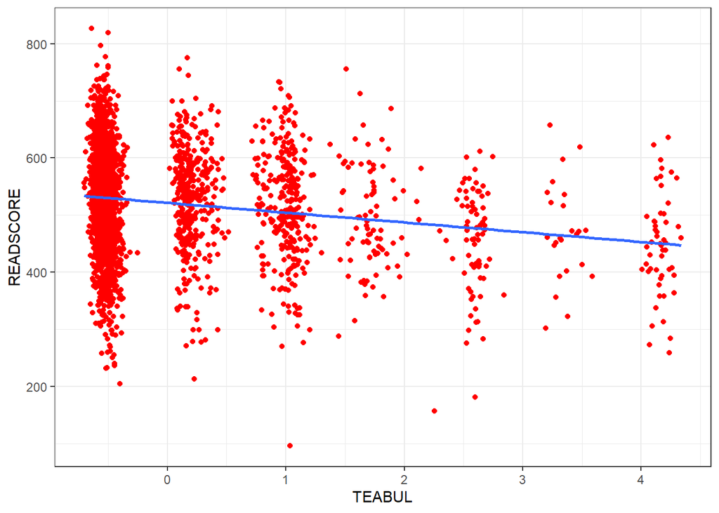

```r
ggplot(train,aes(TEABUL,READSCORE))+
  geom_point(color="red")+
  theme_bw()+
  geom_smooth(method = "lm",se=FALSE)
```

```r
Jaco_mod<- lm(READSCORE~BOOKS+GENDER+BELONG+TEASUPPORT+
                AMBITIONS+PARENTSP+WORRY+TEABUL+DISCORD,data = train)
```

#### observe the coeficients

```r
summary(Jaco_mod)
```

```
##
## Call:
## lm(formula = READSCORE ~ BOOKS + GENDER + BELONG + TEASUPPORT +
##     AMBITIONS + PARENTSP + WORRY + TEABUL + DISCORD, data = train)
##
## Residuals:
##     Min      1Q  Median      3Q     Max
## -504.24  -51.92    3.60   56.61  294.47
##
## Coefficients:
##             Estimate Std. Error t value Pr(>|t|)
## (Intercept)  481.791      4.620 104.280  < 2e-16 ***
## BOOKS         15.796      1.107  14.275  < 2e-16 ***
## GENDERMale   -33.037      3.335  -9.905  < 2e-16 ***
## BELONG        11.080      1.747   6.344 2.61e-10 ***
## TEASUPPORT     1.753      1.791   0.978   0.3279
## AMBITIONS     17.282      1.682  10.276  < 2e-16 ***
## PARENTSP      -2.259      1.606  -1.407   0.1596
## WORRY          4.028      1.691   2.382   0.0173 *
## TEABUL       -11.475      1.680  -6.829 1.05e-11 ***
## DISCORD      -14.139      1.710  -8.269  < 2e-16 ***
## ---
## Signif. codes:  0 '***' 0.001 '**' 0.01 '*' 0.05 '.' 0.1 ' ' 1
##
## Residual standard error: 81.87 on 2776 degrees of freedom
## Multiple R-squared:  0.2219, Adjusted R-squared:  0.2194
## F-statistic: 87.95 on 9 and 2776 DF,  p-value: < 2.2e-16
```

### model 2

```r
Jaco_mod2<-lm(READSCORE~BOOKS+GENDER+BELONG+
                AMBITIONS+WORRY+TEABUL,data = train)
```

#view coefiencts

```r
library(broom)
summary(Jaco_mod2)
```

```
##
## Call:
## lm(formula = READSCORE ~ BOOKS + GENDER + BELONG + AMBITIONS +
##     WORRY + TEABUL, data = train)
##
## Residuals:
##     Min      1Q  Median      3Q     Max
## -478.45  -53.90    4.01   58.20  292.85
##
## Coefficients:
##             Estimate Std. Error t value Pr(>|t|)
## (Intercept)  474.280      4.573 103.722  < 2e-16 ***
## BOOKS         16.780      1.109  15.127  < 2e-16 ***
## GENDERMale   -24.477      3.203  -7.641 2.95e-14 ***
## BELONG        12.175      1.719   7.082 1.79e-12 ***
## AMBITIONS     15.472      1.662   9.308  < 2e-16 ***
## WORRY          4.728      1.641   2.881    0.004 **
## TEABUL       -12.788      1.647  -7.764 1.15e-14 ***
## ---
## Signif. codes:  0 '***' 0.001 '**' 0.01 '*' 0.05 '.' 0.1 ' ' 1
##
## Residual standard error: 82.83 on 2779 degrees of freedom
## Multiple R-squared:  0.2025, Adjusted R-squared:  0.2008
## F-statistic: 117.6 on 6 and 2779 DF,  p-value: < 2.2e-16
```

```r
mod3<-lm(READSCORE~BOOKS+GENDER+AMBITIONS+
           WORRY+TEABUL,data = train)
summary(mod3)
```

```
##
## Call:
## lm(formula = READSCORE ~ BOOKS + GENDER + AMBITIONS + WORRY +
##     TEABUL, data = train)
##
## Residuals:
##     Min      1Q  Median      3Q     Max
## -469.21  -54.11    3.36   58.65  290.41
##
## Coefficients:
##             Estimate Std. Error t value Pr(>|t|)
## (Intercept)  469.159      4.555 103.003  < 2e-16 ***
## BOOKS         17.809      1.109  16.053  < 2e-16 ***
## GENDERMale   -21.313      3.200  -6.660 3.29e-11 ***
## AMBITIONS     19.065      1.597  11.940  < 2e-16 ***
## WORRY          6.795      1.629   4.170 3.13e-05 ***
## TEABUL       -14.385      1.646  -8.739  < 2e-16 ***
## ---
## Signif. codes:  0 '***' 0.001 '**' 0.01 '*' 0.05 '.' 0.1 ' ' 1
##
## Residual standard error: 83.56 on 2780 degrees of freedom
## Multiple R-squared:  0.1881, Adjusted R-squared:  0.1867
## F-statistic: 128.8 on 5 and 2780 DF,  p-value: < 2.2e-16
```

### add predictions to the test dataset

```r
test$pred<-predict(Jaco_mod2,newdata = test)
```

### visualise predictions vs actual score

shows a linear relationship between the actual and predicted values

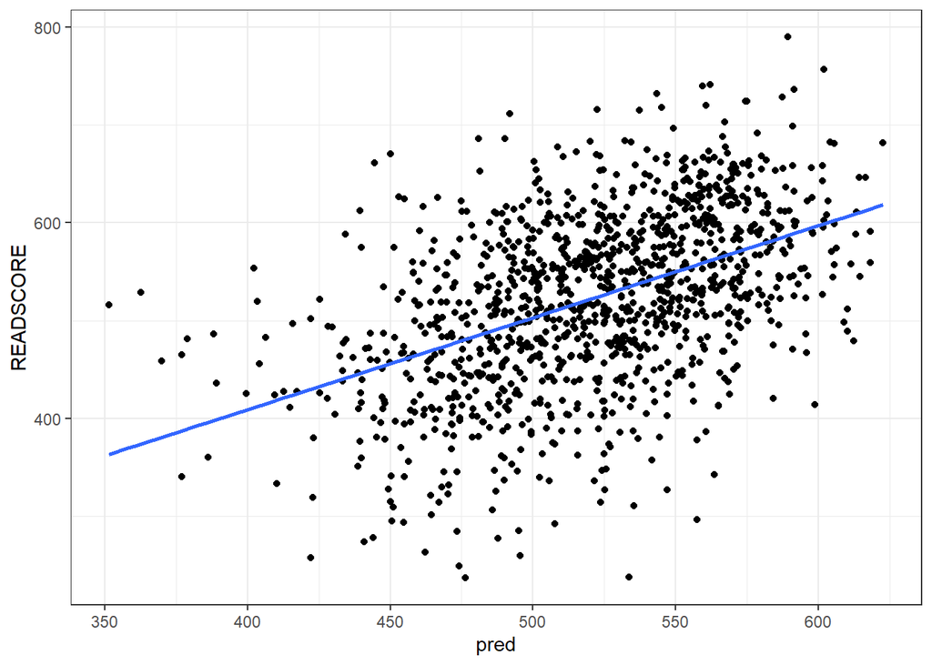

```r
test %>% ggplot(aes(pred,READSCORE))+
  geom_point()+
  geom_smooth(method = "lm",se=FALSE)+
  theme_bw()
```

### model performance

model with all predictors has a better fit based on AIC and R squared

```r
glance(Jaco_mod)$adj.r.squared
```

```
## [1] 0.2193573
```

```r
glance(Jaco_mod2)$adj.r.squared
```

```
## [1] 0.2007873
```

```r
glance(mod3)$adj.r.squared
```

```
## [1] 0.1866563
```

```r
AIC(Jaco_mod,Jaco_mod2) %>% arrange(desc(AIC))
```

```
##           df      AIC
## Jaco_mod2  8 32526.00
## Jaco_mod  11 32463.49
```

```r
tidy(Jaco_mod2) %>% knitr::kable(caption = "Table: regression coefients",digits = 2)
```

Table: regression coefients

| term | estimate | std.error | statistic | p.value |
| --- | --- | --- | --- | --- |
| (Intercept) | 474.28 | 4.57 | 103.72 | 0 |
| BOOKS | 16.78 | 1.11 | 15.13 | 0 |
| GENDERMale | -24.48 | 3.20 | -7.64 | 0 |
| BELONG | 12.17 | 1.72 | 7.08 | 0 |
| AMBITIONS | 15.47 | 1.66 | 9.31 | 0 |
| WORRY | 4.73 | 1.64 | 2.88 | 0 |
| TEABUL | -12.79 | 1.65 | -7.76 | 0 |

```r
library(Metrics)
train$PRED<-predict(Jaco_mod)
rmse(train$READSCORE,train$PRED)
```

```
## [1] 81.71977
```

```r
tab_model(Jaco_mod,Jaco_mod2)
```

|  | READSCORE |  |  | READSCORE |  |  |
| --- | --- | --- | --- | --- | --- | --- |
| Predictors | Estimates | CI | p | Estimates | CI | p |
| (Intercept) | 481.79 | 472.73 – 490.85 | **<0.001** | 474.28 | 465.31 – 483.25 | **<0.001** |
| BOOKS | 15.80 | 13.63 – 17.97 | **<0.001** | 16.78 | 14.61 – 18.96 | **<0.001** |
| GENDER [Male] | -33.04 | -39.58 – -26.50 | **<0.001** | -24.48 | -30.76 – -18.20 | **<0.001** |
| BELONG | 11.08 | 7.66 – 14.51 | **<0.001** | 12.17 | 8.80 – 15.55 | **<0.001** |
| TEASUPPORT | 1.75 | -1.76 – 5.26 | 0.328 |  |  |  |
| AMBITIONS | 17.28 | 13.98 – 20.58 | **<0.001** | 15.47 | 12.21 – 18.73 | **<0.001** |
| PARENTSP | -2.26 | -5.41 – 0.89 | 0.160 |  |  |  |
| WORRY | 4.03 | 0.71 – 7.34 | **0.017** | 4.73 | 1.51 – 7.95 | **0.004** |
| TEABUL | -11.48 | -14.77 – -8.18 | **<0.001** | -12.79 | -16.02 – -9.56 | **<0.001** |
| DISCORD | -14.14 | -17.49 – -10.79 | **<0.001** |  |  |  |
| Observations | 2786 |  |  | 2786 |  |  |
| R<sup>2</sup> / R<sup>2</sup> adjusted | 0.222 / 0.219 |  |  | 0.203 / 0.201 |  |  |

```r
library(modelsummary)
msummary(list(Jaco_mod,Jaco_mod2), # List the models to include
         stars = TRUE)
```

|  | Model 1 | Model 2 |
| --- | --- | --- |
| (Intercept) | 481.791*** | 474.280*** |
|  | (4.620) | (4.573) |
| BOOKS | 15.796*** | 16.780*** |
|  | (1.107) | (1.109) |
| GENDERMale | -33.037*** | -24.477*** |
|  | (3.335) | (3.203) |
| BELONG | 11.080*** | 12.175*** |
|  | (1.747) | (1.719) |
| TEASUPPORT | 1.753 |  |
|  | (1.791) |  |
| AMBITIONS | 17.282*** | 15.472*** |
|  | (1.682) | (1.662) |
| PARENTSP | -2.259 |  |
|  | (1.606) |  |
| WORRY | 4.028* | 4.728** |
|  | (1.691) | (1.641) |
| TEABUL | -11.475*** | -12.788*** |
|  | (1.680) | (1.647) |
| DISCORD | -14.139*** |  |
|  | (1.710) |  |
| Num.Obs. | 2786 | 2786 |
| R2 | 0.222 | 0.203 |
| R2 Adj. | 0.219 | 0.201 |
| AIC | 32463.5 | 32526.0 |
| BIC | 32528.7 | 32573.5 |
| Log.Lik. | -16220.745 | -16254.999 |
| F | 87.953 | 117.613 |
| RMSE | 81.72 | 82.73 |

+ p < 0.1, * p < 0.05, ** p < 0.01, *** p < 0.001